# The Blue Water Potential Toolkit

A socio-hydrological framework to scale water budgets from plot to agrarian system.

Authors

Rutuja Chitra-Tarak

Charlotte Hemingway

Claire Aubron

Mathieu Vigne

Gilles Boulet

Sekhar Muddu

Laurent Ruiz

# 1 Overview

This document serves as the main reproducible report and computational workflow for Hemingway et al. (2026). *Accounting for the unaccounted: a new framework for incorporating farm social diversity in micro-regional water budgets*. Journal of Hydrology. 681, 136621. https://doi.org/10.1016/j.jhydrol.2026.136621

**The Blue Water Potential Toolkit** provides a generalized R framework for simulating Blue Water Potential (Gross Groundwater Recharge minus Irrigation Requirement) at plot, farm, and village/micro-regional scale. By coupling climate, soil and crop information with socio-agricultural data, this toolkit computes and displays water fluxes, revealing how different types of farms can be either net consumers or net producers of blue water in a given climate. The BWP calculations follow the FAO-56 method to compute the crop-level water balance, with the equations and assumptions presented in the Methods section and in the Supplementary Material of Hemingway et al. (2026).

While the specific implementation is configured to reproduce the results and figures for the case study in Hemingway et al. (2026), the underlying R code is highly modular. It is designed as a toolkit that can be easily adapted to any case study globally, using local meteorological and cropping system data.

> 💡 **Using this Toolkit:** See the repository `README.md` for full instructions on how to adapt this framework using your own processed site data and how to cite this toolkit.

### 1.0.1 🗂️ Data Architecture & Workflow

This script acts as the primary **Hydrological Model**. It bridges the user’s static inputs with the dynamically generated phenology curves: 1. It reads the static weather, soil, and demographic data directly from `data/input/`. 2. It pairs them with the derived phenology ($K_c$) curves from `data/processed/` (which were generated by `01_Prepare_Model_Input.qmd`). 3. It executes the multi-decadal water budget simulations and automatically routes the results and publication-ready visualizations to the `output/` and `figures/` directories.

### 1.0.2 📂 Directory Structure for this Script

This script assumes you have already placed your CSVs in `data/input/` and run `01_Prepare_Model_Input.qmd`. To run this script and generate the report, open the `.Rproj` and click “Render”.

```
project_root/
├── data/
│   ├── input/                       <- Required: Static parameters (Climate, Soil, Demographics)
│   └── processed/                   <- Required: Dynamic curves from the 01_Input script
│       ├── 01_crop.systems.l.kc.csv
│       └── supplementary/01_crop_kc_by_doy_all_crops.csv
├── code/
│   ├── functions/                   <- Required: Core toolkit dependencies
│   │   ├── 02_get_Peff.R
│   │   ├── 03_get_budget.R
│   │   ├── 04_get_figures.R
│   │   └── 05_case_study_formatters.R
│   ├── 01_Format_Input_Data.qmd     <- Run 1st: Generates processed Kc curves
│   └── 02_Blue-Water.qmd            <- (This file)
├── output/                          <- Generated: Final budget CSV summaries
├── figures/                         <- Generated: Root folder for all visualizations
│   ├── manuscript/                  <- Generated: High-res print-ready PDFs
│   └── presentation/                <- Generated: Screen-ready PNGs and web layouts
├── Blue-Water.Rproj                 <- Required: RStudio Project file to render this script
└── 02_Blue-Water.html               <- Generated: HTML Report created by rendering this script
```

## 1.1 User Configuration

If you are running this script for your own data but you don’t have data at all scales, you can limit the scale of the analyses here.

The main Water Budget function calculations can be turned ON/OFF here.

```r
# ~~~~~~~~~~~~~~~~~~~~~~~~~~~~~~~~~~~~~~~~~~~~~~~~~~~~~~~~~~~~~~
# 2. If applying for your study site, is production or production as well as agrarian system scale data missing? ----
# ~~~~~~~~~~~~~~~~~~~~~~~~~~~~~~~~~~~~~~~~~~~~~~~~~~~~~~~~~~~~~~

# By default, the script runs the full suite at village/micro-region (requires files processed/01 to 10 mentioned above in the 📂 Directory Structure for this Script).

# Set this if you have limited data!
HAS_PRODUCTION_SYSTEM <- TRUE # Set to FALSE to Stop at Cropping Systems (requires ONLY processed/01 to 09 data files).
HAS_AGRARIAN_SYSTEM <- TRUE # Set to FALSE to Stop at Production Systems (requires ONLY processed/01 to 10 data files).

# The main Water Budget Calculator function can be turned ON/OFF here.
CALCULATE_BUDGET <- FALSE # Toggle this to FALSE, for example, if you have already run the water budget calculations once (so budget outputs are saved), and are manipulating the output processing code.
```

## 1.2 Load Toolkit Dependencies

These external modular scripts handle the mathematical heavy lifting behind the scenes, processing forcing variables such as daily reference evapotranspiration ($ET_0$), effective precipitation ($P_{eff}$), and generating the core plot architectures.

```r
source(here::here("code/functions/02_get_Peff.R"))
source(here::here("code/functions/03_get_budget.R"))
source(here::here("code/functions/04_get_figures.R"))
source(here::here("code/functions/05_case_study_formatters.R"))
```

# 2 Input Data Preview

Below, we ingest the processed climate series and provide brief data previews.

```r
sitename <- "Anantapur"
# Meteorological Forcing
precip <- utils::read.csv(file = here::here("data/input/02_precipitation.csv"), header = TRUE)
years.range <- range(as.numeric(format(strptime(precip$date, format = "%Y-%m-%d"), format = "%Y")))
years.range.plot <- paste(years.range[1], ":", years.range[2])

et0 <- utils::read.csv(file = here::here("data/input/03_et0.csv"), header = TRUE)
et0.timestep = "daily"

# Display Previews
knitr::kable(head(precip, 3), caption = "Preview: Precipitation Data Sample")
```

Preview: Precipitation Data Sample

| date | p |
| --- | --- |
| 1980-01-01 | 0 |
| 1980-01-02 | 0 |
| 1980-01-03 | 0 |

```r
knitr::kable(head(et0, 3), caption = "Preview: Reference ET0 Data Sample")
```

Preview: Reference ET0 Data Sample

| date | et0 |
| --- | --- |
| 1980-01-01 | 3.799466 |
| 1980-01-02 | 4.036208 |
| 1980-01-03 | 4.315340 |

## 2.1 Climatological Profile Summary

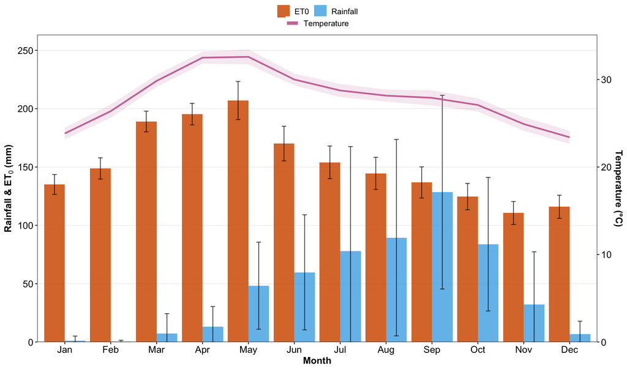

Figure 1. Monthly mean (± SD; 1980-2018) rainfall, temperature, and reference evapotranspiration. This figure corresponds to Figure 1 in Hemingway et al. (2026)

## 2.2 Soils and Crops

```r
# Soil Parameters
soil.param <- utils::read.csv(file = here::here("data/input/04_soil.parameters.csv"), header = TRUE)
knitr::kable(soil.param, caption = "Preview: Soil Parameter")
```

Preview: Soil Parameter

| soil | soil.type | whc.mmpercm | raw | CN | lambda |
| --- | --- | --- | --- | --- | --- |
| 1 | RED LOAMY | 1.7 | 1 | 85 | 0.3 |
| 2 | GREY CLAYEY | 1.8 | 1 | 85 | 0.2 |

```r
# Crop Rooting Depth & Rainfed/Irrigated Crop
crop.param <- utils::read.csv(file = here::here("data/input/05_crop.parameters.csv"), header = TRUE)
knitr::kable(head(crop.param), caption = "Preview: Crop Rooting Depth and Rainfed/Irrigated Crop")
```

Preview: Crop Rooting Depth and Rainfed/Irrigated Crop

| crop | irrigation | rooting_depth_cm |
| --- | --- | --- |
| No Crop | rainfed | 0 |
| Rice Long | irrigated | 50 |
| Rice Short Monsoon | irrigated | 50 |
| Rice Short Summer | irrigated | 50 |
| Groundnut Summer | irrigated | 70 |
| Banana 2 | irrigated | 65 |

```r
### Kc Curves for All Crops
kc.doy.crop.all <- utils::read.csv(file =  here::here("data/processed/supplementary/01_crop_kc_by_doy_all_crops.csv"), header = TRUE)
knitr::kable(head(kc.doy.crop.all), caption = "Preview: Crop Daily Kc")
```

Preview: Crop Daily Kc

| crop | doy | kc |
| --- | --- | --- |
| Banana 1 Beg | 1 | 0 |
| Banana 1 Beg | 2 | 0 |
| Banana 1 Beg | 3 | 0 |
| Banana 1 Beg | 4 | 0 |
| Banana 1 Beg | 5 | 0 |
| Banana 1 Beg | 6 | 0 |

### 2.2.1 Plotting All Crop Kc Curves

*(Saves a high-resolution PDF for the manuscript).*

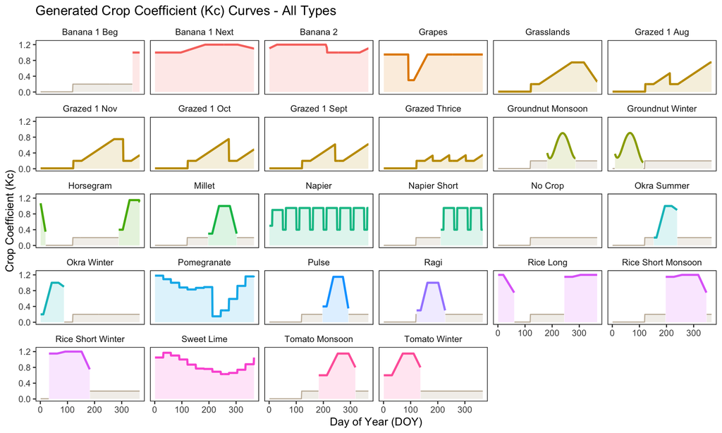

**Figure 2. Daily crop coefficient ($K_c$) for all modeled crops.** The panels illustrate the temporal variation of $K_c$ across a full calendar year (Day of Year), generated via crop-specific mathematical rule sets. The profiles integrate multiple modeling approaches: standard FAO-56 segmented linear growth stages for seasonal crops (e.g., millet, rice, tomato, pulses), continuous polynomial equations for groundnut varieties, discrete monthly step-functions for specific perennial orchards (sweet lime, pomegranate), and drop-and-regrowth cycles to simulate managed grazing and repeated harvesting schedules (grazed pastures, Napier grass).Off-season periods are defaulted to a defined seasonal threshold representing bare-soil evaporation (tan sections).

```r
if (!dir.exists(here::here("figures/manuscript"))) {
  dir.create(here::here("figures/manuscript"), recursive = TRUE, showWarnings = FALSE)
}

# Apply the local names and generate the plot
kc_corrected <- rename_local_indian_seasons(kc.doy.crop.all)
fig.2_journal <- plot_crop_coefficient_curves(kc_corrected)
print(fig.2_journal)
```

```r
# Save PDF for Manuscript
ggplot2::ggsave(here::here("figures/manuscript/Fig.2_Kc_Curves_All_Crops.pdf"), plot = fig.2_journal, width = 10, height = 6)

# Save PNG for Presentation
ggplot2::ggsave(plot = fig.2_journal, filename = here::here("figures/presentation/Fig.2_Kc_Curves_All_Crops.png"), width = 180, height = 120, units = "mm", dpi = 300, bg = "white", device = ragg::agg_png)
```

## 2.3 Cropping Systems

```r
# Cropping Systems
crop.systems <- utils::read.csv(file = here::here("data/input/08_crop.systems.csv"), header = TRUE)

knitr::kable(head(crop.systems), caption = "Preview: Cropping Systems")
```

Preview: Cropping Systems

| crop.system | Irrigation | n.rotation | rotation | soil | crop_1 | crop_2 | crop_3 |
| --- | --- | --- | --- | --- | --- | --- | --- |
| Finger Millet/Rice | Irrigated | 1 | Ragi Rice | 2 | Ragi | Rice Long | No Crop |
| Millets/Fallow | Rainfed | 1 | Millet | 1 | Millet | No Crop | No Crop |
| Pulses/Fallow | Rainfed | 1 | Pulse | 1 | Pulse | No Crop | No Crop |
| Grasslands (Grazed Once) | Rainfed | 1 | Grazed 1 Aug | 1 | Grazed 1 Aug | No Crop | No Crop |
| Grasslands (Grazed Once) | Rainfed | 1 | Grazed 1 Sept | 1 | Grazed 1 Sept | No Crop | No Crop |
| Grasslands (Grazed Once) | Rainfed | 1 | Grazed 1 Oct | 1 | Grazed 1 Oct | No Crop | No Crop |

```r
# Kc Curves by Cropping Systems
crop.systems.l.kc <- utils::read.csv(file = here::here("data/processed/01_crop.systems.l.kc.csv"), header = TRUE)
```

#### 2.3.0.1 Kc Curves for each Cropping System

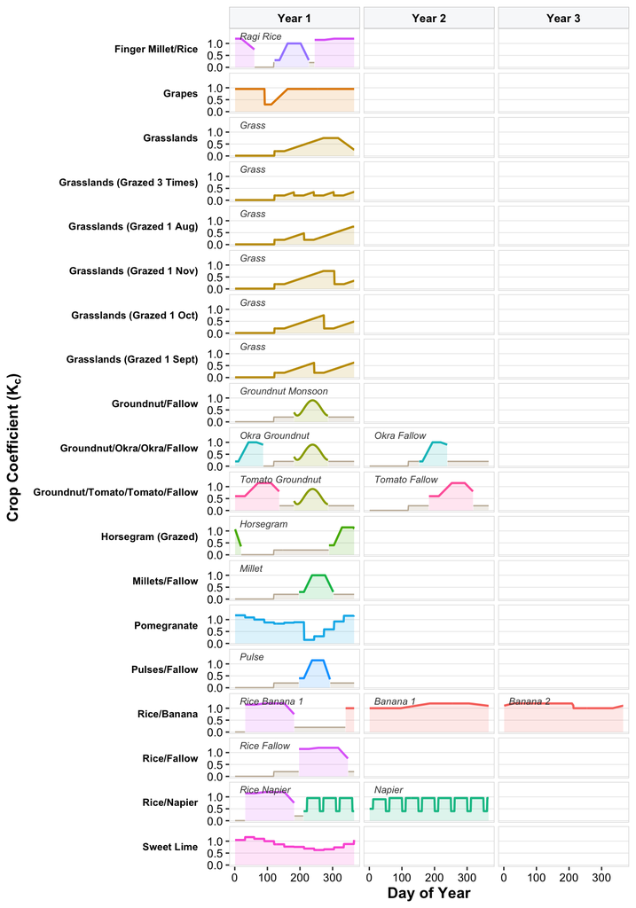

Figure 3. Annual Crop Coefficient (Kc) curves for each cropping system (rows) for one year (column 1), an average year (column 1; e.g., Finger Millet/Rice and Horsegram), or multi-year (columns 1-2 or 1-3) rotations, color coded by crop. Off-season and ‘No Crop’ periods are defaulted to a defined seasonal threshold representing bare-soil evaporation (tan sections).

## 2.4 Production Systems

These files map the cropping systems to Production Systems or farm types.

```r
# ⚠️ **Note to Users:** The following section executes **Scale 2** of this toolkit and requires data files: processed/01 to 08). If you have set `HAS_AGRARIAN_SYSTEM <- FALSE` in the setup chunk, then scale beyond Scale 2 in this document will be intentionally skipped during rendering.

ps_by_cs_area <- utils::read.csv(file = here::here("data/input/09_crop_system_area_by_production_system.csv"), header = TRUE)

# Automatically fix typos before the water budget calculator processes them
ps_by_cs_area <- harmonize_crop_system_names(ps_by_cs_area, crop.systems)

knitr::kable(head(ps_by_cs_area), caption = "Preview: Cropping Systems and their Areas within each Production System")
```

Preview: Cropping Systems and their Areas within each Production System

| time_period | report_group_name | production_system | sub_production_system | crop.system | land_use_type | area_ha |
| --- | --- | --- | --- | --- | --- | --- |
| 1950 | Large landholders | Large landholders | Large landholders | Finger Millet/Rice | Irrigated | 1.21 |
| 1950 | Large landholders | Large landholders | Large landholders | Grasslands | Grasslands | 0.67 |
| 1950 | Large landholders | Large landholders | Large landholders | Grasslands (Grazed Once) | Grazed | 14.20 |
| 1950 | Large landholders | Large landholders | Large landholders | Groundnut/Fallow | Rainfed | 3.60 |
| 1950 | Large landholders | Large landholders | Large landholders | Millets/Fallow | Rainfed | 1.80 |
| 1950 | Large landholders | Large landholders | Large landholders | Pulses/Fallow | Rainfed | 2.13 |

## 2.5 Agrarian Systems

Number of farms belonging to each of the Production Systems in the Agrarian System of the considered area (village, micro-region, watershed).

```r
# ⚠️ **Note to Users:** The following section executes **Scale 3** of this toolkit and requires all data files: processed/01 to 09). By default, that is when all `HAS_AGRARIAN_SYSTEM <- TRUE` in the setup chunk, the script will run till the end. "Preview: Number of farms belonging to each of the Production Systems"

farms_count_df <- utils::read.csv(file = here::here("data/input/10_no_of_farmers_by_production_system.csv"), header = TRUE)

knitr::kable(head(farms_count_df), caption = "Preview: Number of Farms belonging to each Production System")
```

Preview: Number of Farms belonging to each Production System

| time_period | production_system | sub_production_system | number_of_farms |
| --- | --- | --- | --- |
| 1950 | Large landholders | Large landholders | 8 |
| 1950 | Smallholders | Smallholders | 80 |
| 1950 | Pastoralists | Pastoralists | 8 |
| 1950 | Landless households | Landless | 64 |
| 2022 | Vegetable growers_dairy farming | Vegetable growers (dairy farming) | 21 |
| 2022 | Vegetable growers_no livestock | Vegetable growers (no livestock) | 20 |

# 3 Water Budget Calculator

We first transform precipitation series into site-specific effective inputs ($P_{eff}$), governed by the SCS Curve Number ($CN$) depending on soil type to account for surface runoff, before initializing the core water budget calculator.

```r
p.list <- base::list(
  precip = precip,
  et0 = et0,
  et0.timestep = et0.timestep, # Weekly or daily
  soil.input = get_param("soil_input", FALSE), # For the case study in Hemingway et al (2026), we assume effective precipitation (Peff) = precipitation. So, calculated Peff is not being used. Set soil.input <- "Peff", if you want to get runoff.
  soil.param = soil.param,
  sm.init = get_param("sm_init"), # Initial soil water content
  crop.param = crop.param,
  # Kc value depending on seasons governing bare-soil evaporation.
  kc_no_crop = KC_FALLOW_CONSTANTS # Given in section # Kc Curves for Crop Systems
)

# The Water Budget Calculator operates on individual rotations
crop.rotation.kc.ls <- base::split(crop.systems.l.kc, crop.systems.l.kc$rotation)

# Vectorized generation of effective precipitation models across targeted soil horizons
met.forcing.ls <- base::lapply(base::as.list(soil.param$soil), function(x) {
  get_peff_et0(p = p.list, soil_id = x)
})
base::names(met.forcing.ls) <- soil.param$soil
```

> **Parallel Processing** Simulating multi-decadal daily water fluxes across dozens of crop rotations is computationally expensive. The code block below detects the number of available physical cores on your machine and parallelizes the tasks, drastically reducing execution time.

When the calculator finishes running, all daily data outputs are saved as well as aggregated by year (and month) as well as summaries across years (and months) in a single Rdata file:  
“output/01_processed_water_budgets.Rdata”

```r
# Multi-Core Setup
num_cores <- parallel::detectCores(logical = FALSE)
cl <- parallel::makeCluster(num_cores, type = "PSOCK")

parallel::clusterExport(cl, varlist = c("p.list", "met.forcing.ls", "get_budget"), envir = environment())
invisible(parallel::clusterEvalQ(cl, {library(tidyverse); library(ggpubr); library(here)}))

# Process budget arrays iteratively
budget <- pbapply::pblapply(crop.rotation.kc.ls, get_budget, cl = cl, p = p.list, ts = met.forcing.ls)
parallel::stopCluster(cl)

names(budget) <- names(crop.rotation.kc.ls)
base::save(budget, file = here::here("output/01_processed_water_budgets.Rdata"))
```

```r
# Internal loading mechanism to bypass lengthy re-calculations during document knitting
# (Ensure the Calculator block has been run at least once locally)
base::load(file = here::here("output/01_processed_water_budgets.Rdata"))
```

# 4 Output Processing & BWP Calculations

We transform the “output/01_processed_water_budgets.Rdata”) file into CSVs of:  
1. Daily outputs: “output/02_export_detailed_daily_water_budgets.csv”,  
2. Yearly outputs: “output/03_export_annual_water_budgets_long.csv”, and  
3. For an average year (with SD across years):  
3.1. All water budget variables:  
“output/04_crop_system_water_budget_outputs_for_an_avg_year_with_sd.csv”  
3.2. Only Blue Water Potential:  
“output/05_crop_system_blue_water_potential_for_an_avg_year_with_sd.csv”

```r
# 1. Optimize Daily Processing
budget.daily.ls <- lapply(budget, function(x) {return(x$ts)})

# data.table::rbindlist is exponentially faster than dplyr::bind_rows for large lists
budget.daily <- data.table::rbindlist(budget.daily.ls, idcol = "rotation") %>%
  dplyr::left_join(crop.systems, by = "rotation")

# readr::write_csv is massively faster than base write.csv
readr::write_csv(budget.daily, file = here::here("output/02_export_detailed_daily_water_budgets.csv"))

# 2. Optimize Annual Processing
budget.yr.ls <- lapply(budget, function(x) {return(x$sum.yr)})
budget.yr.l <- data.table::rbindlist(budget.yr.ls, idcol = "rotation") %>%
    tidyr::pivot_longer(cols = c(-rotation, -year), names_to = "var", values_to = "value") %>%
    dplyr::left_join(crop.systems, by = "rotation")

readr::write_csv(budget.yr.l, file = here::here("output/03_export_annual_water_budgets_long.csv"))

# Save water budget outputs an average year (with median and 95% quantiles across years)
summary_yr_budgets <- process_annual_budget(budget, crop.systems)
summ.qs.cs <- summary_yr_budgets$summ_qs_cs

readr::write_csv(summ.qs.cs, file = here::here("output/04_crop_system_water_budget_outputs_for_an_avg_year_with_sd.csv"))

# Process the Blue Water Potential (BWP)
bwp <- summ.qs.cs %>%
  base::subset(var == "balance") %>%
  dplyr::select(-var, -var.plot)
colnames(bwp)[-c(1,2)] <- paste0("BWP_", colnames(bwp)[-c(1,2)])

readr::write_csv(bwp, file = here::here("output/05_crop_system_blue_water_potential_for_an_avg_year_with_sd.csv"))
```

# 5 Blue Water Potential at Cropping System Scale

## 5.1 Annual Summaries of Irrigation Requirement and Gross Groundwater Recharge

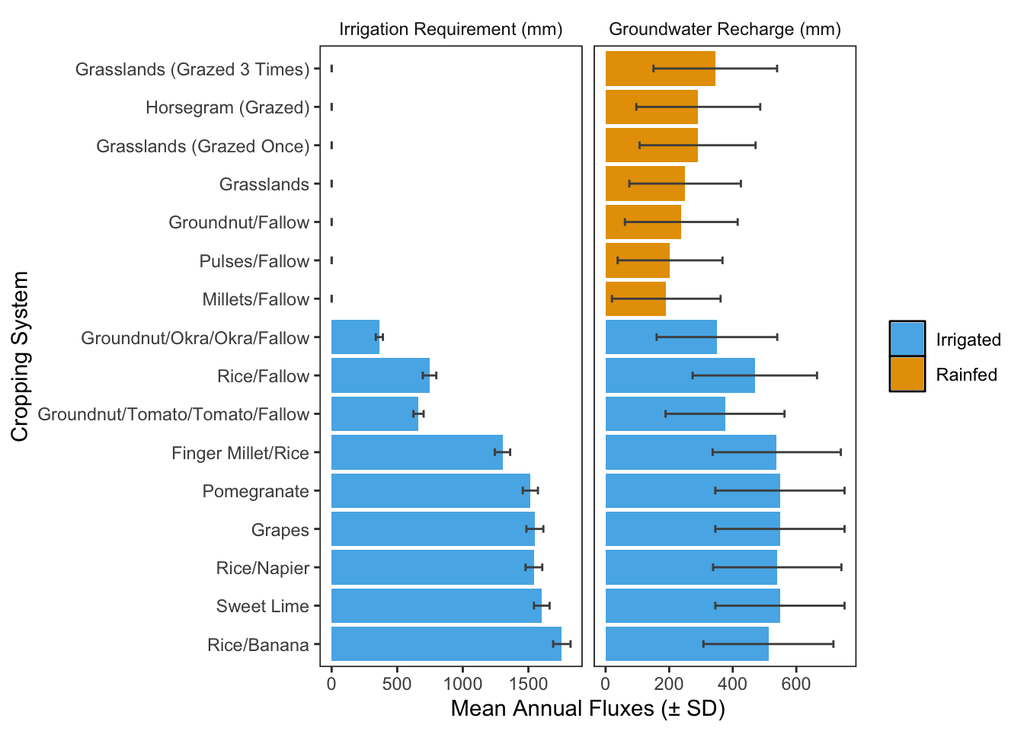

Figure 4. Annual mean (± SD; 1980-2018) of irrigation requirement of irrigated cropping systems and the gross groundwater recharge for all cropping systems (color coded by Irrigated or Rainfed).

## 5.2 Blue Water Potential ($BWP$) by Cropping Systems

This plot displays the core metric: **Blue Water Potential**, which is the mean annual Net Groundwater Recharge, calculated as the difference between Gross Groundwater Recharge and Irrigation Requirement (mm).

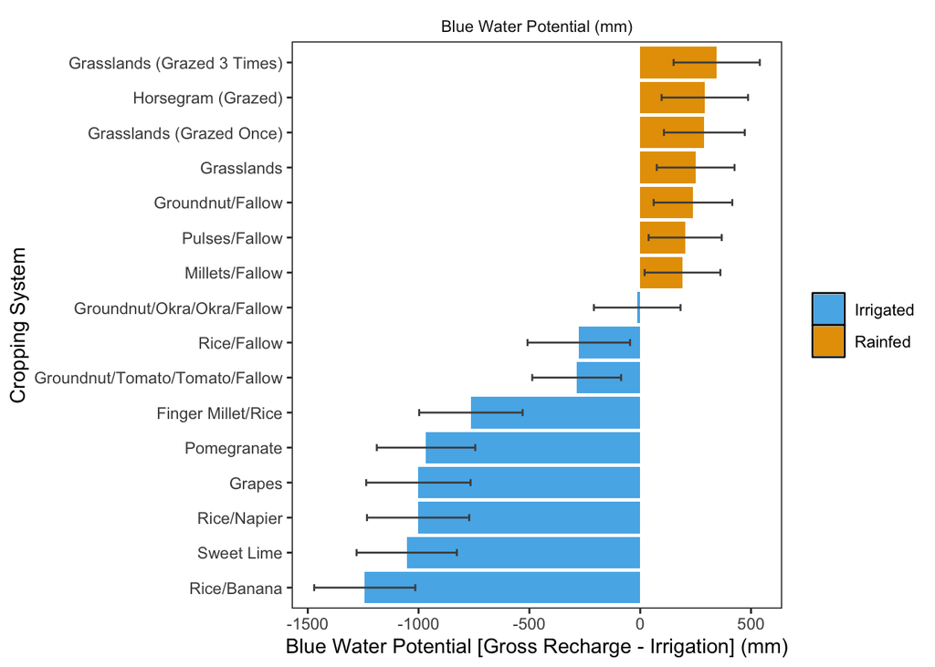

Figure 5. Annual mean (± SD; 1980-2018) of Blue Water Potential for various cropping systems (color coded by Irrigated or Rainfed). This figure corresponds to Fig. 4 in Hemingway et al. (2026).

# 6 Blue Water Potential at Production System Scale

Here we show the aggregated Blue Water Potential of the different cropping systems within each production system (social category of farmer),

> 🔍 **Understanding Net Consumers vs. Net Producers**
> - **Production Systems with $BWP < 0$:** are Net Consumers of groundwater in the current climate of the study site because their irrigation demand exceeds gross recharge over their area. On the long term they can sustain only if groundwater recharge is supplied by others inside or outside the watershed.
> - **Production Systems with ($BWP > 0$):** are Net Producers of groundwater in the current climate of the study site because either they are fully rainfed or because their area under irrigation is small compared to the rainfed area. On the long term they contribute to the Blue Water Commons of the area that help sustains the Net Consumers.

```r
ps_results <- get_production_system_budgets(budget.yr.l, ps_by_cs_area, farms_count_df)

ps_budget_summary  <- ps_results$ps_budget_summary
ps_volumetric_summary <- ps_results$ps_volumetric_summary
ps_bwp_volumetric <- ps_results$ps_bwp_volumetric

utils::write.csv(ps_bwp_volumetric, file = here::here("output/06_production_system_bwp_contributions.csv"), row.names = FALSE)
```

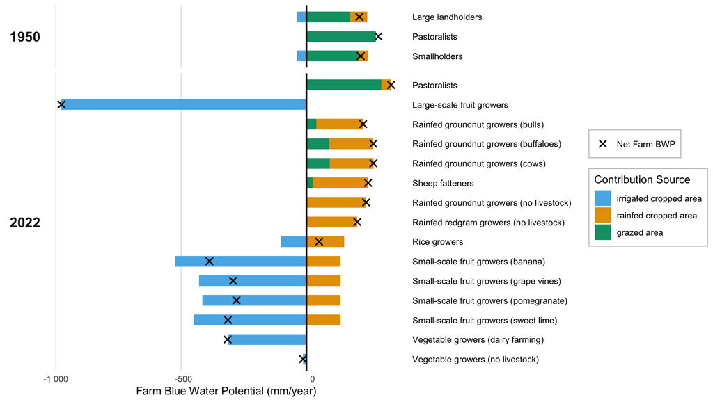

Figure 6. Comparative annual Blue Water Potential ($BWP$) across Production Systems, or farm types, (1950s vs. 2022). BWP contributions (+ve or -ve) from Irrigated/Rainfed cropped area, or grazed area within each farm type are mapped by colors. Net BWP contribution of each farm type is identified by a cross. This figure corresponds to Fig. 5 in Hemingway et al. (2026).

```r
fig.6_social <- plot_production_system_bwp(ps_bwp_volumetric)
print(fig.6_social)
```

```r
# Save PDF for Manuscript
ggplot2::ggsave(here::here("figures/manuscript/Fig.6_Socio_Economic_Group_BWP.pdf"), fig.6_social, width = 10, height = 5.65, device = grDevices::cairo_pdf)

# Save PNG for Presentation
ggplot2::ggsave(here::here("figures/presentation/Fig.6_Socio_Economic_Group_BWP.png"), fig.6_social, width = 10, height = 5.65, dpi = 300, bg = "white", device = ragg::agg_png)
```

# 7 Blue Water Potential at Agrarian System Scale

## 7.1 Contribution of Production Systems to Annual Blue Water Potential at Village Scale

Finally, we aggregate the Blue Water Potential of all the production systems, or Social Categories of Farmers, to understand how they contribute to the Blue Water Potential of the agrarian system. In the case study of Hemingway et al. (2026), this is done at the scale of the archetype village, at two historical periods: 1950s and 2022. The composition of each production system in terms of cropping systems and their area was taken from Tables 1 & 2 of Hemingway et al. (2025) and modified in Hemingway et al. (2026a). In the 1950s, all the social category had a positive Blue Water Potential (and were thus Net Producers), while in 2022 the social categories are divided in Net Consumers and Net Producers.

This figure highlights the role of often overlooked social categories with no access to groundwater, such as pastoralists and rainfed farmers, who in 2022 are important net contributors to Blue Water production in the archetype village.

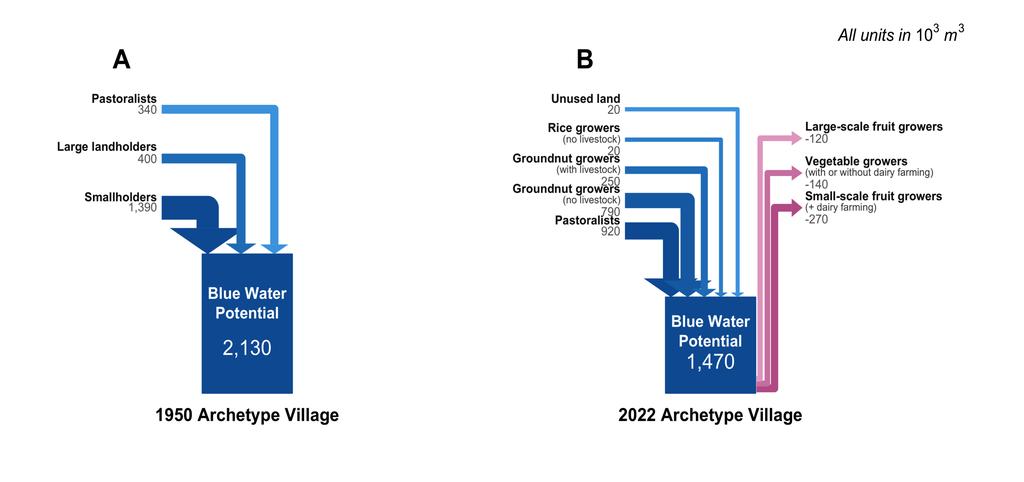

Figure 7. Annual Blue Water Potential of the archetype village in the 1950s (left) and 2022 (right). This figure corresponds to Fig. 6 in Hemingway et al. (2026).

```r
cfg <- list(box_width = 100, min_arrow_w = 5, max_arrow_w = 30, v_stagger_out = 3000)

# Build comprehensive system maps
invisible(plot_village_bwp(
  ps_bwp_volumetric = ps_bwp_volumetric,
  ps_by_cs_area = ps_by_cs_area,
  cfg = cfg,
  output_dev = grDevices::cairo_pdf,
  filename = here::here("figures/manuscript/Fig.7_Historical_Village_BWP_Comparison.pdf"),
  manuscript_style = TRUE,
  save_csv_path = here::here("output/07_village_bwp_fig_data.csv") # Automatically exports the CSV!
))
invisible(plot_village_bwp(
  ps_bwp_volumetric = ps_bwp_volumetric,
  ps_by_cs_area = ps_by_cs_area,
  cfg = cfg,
  output_dev = grDevices::png,
  filename = here::here("figures/presentation/Fig.7_Historical_Village_BWP_Comparison_box.png"),
  manuscript_style = FALSE
))

invisible(plot_village_bwp(
  ps_bwp_volumetric = ps_bwp_volumetric,
  ps_by_cs_area = ps_by_cs_area,
  cfg = cfg,
  output_dev = grDevices::png,
  filename = here::here("figures/presentation/Fig.7_Historical_Village_BWP_Comparison.png"),
  manuscript_style = TRUE
))
# knitr::include_graphics("../figures/presentation/Fig.8_Historical_Village_BWP_Water_Tank_Comparison.png")
# THE FIX: Read the generated image back into R and natively plot it
# This forces knitr to natively embed it without pathing conflicts.
img_path <- here::here("figures/presentation/Fig.7_Historical_Village_BWP_Comparison.png")
if (file.exists(img_path)) {
  img <- png::readPNG(img_path)
  graphics::par(mar = c(0,0,0,0))
  graphics::plot.new()
  graphics::rasterImage(img, 0, 0, 1, 1)
}
```

## 7.2 Classical Representation of Water Balance

Here we illustrate how water balance is commonly represented as aggregated Inflows minus Outflows by land-use. In contrast to the new framework (as illustrated in the last figure), here all land uses are represented as net water consumers. This representation ignores the complementarity between land-uses for the Blue Water Balance at the village/micro-regional scale and can lead to maladaptive management decisions (e.g., getting rid of pastoral systems, or replacement of rainfed crops by irrigated crops).

A. 1950s Archetype Village

[interactive chart not shown]

B. 2022 Archetype Village

[interactive chart not shown]

Figure 8. Average annual water balance of the archetype village. This figure corresponds to Fig. 7 in Hemingway et al. (2026).

## 7.3 Impact of Social Category Demographics on Blue Water Potential of the Village

While the per-hectare and per-farm budgets reveal the Blue Water Potential of different farming practices, the ultimate sustainability of the village groundwater system depends on the demographic weight of each farm type.

This figure shows how some social category (Production System) disproportionately affect the Blue Water Potential of the village/micro-region.

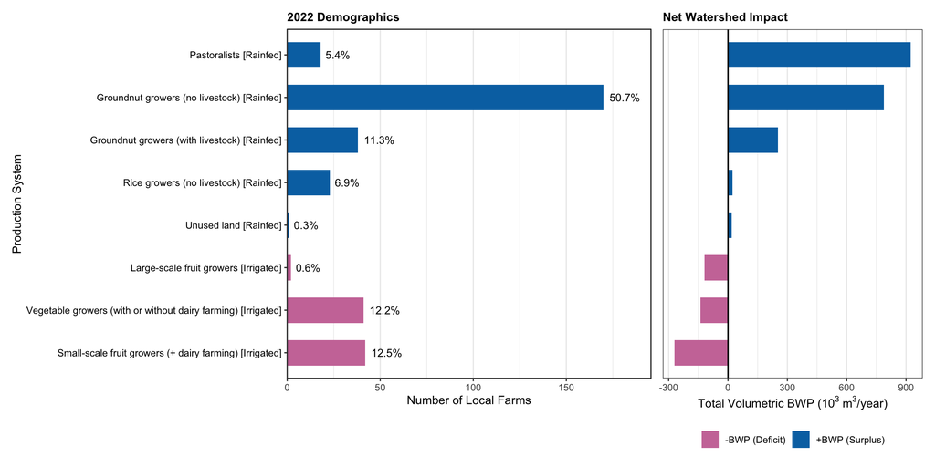

Figure 9. Number of farmers in each Production System (left panel) and their aggregated Blue Water Potential (BWP) (right panel; in thousand m³). The bracketed labels indicate the system’s dominant water source category: a production system is classified as [Irrigated] if more than 40% of its cultivated area receives irrigation, and [Rainfed] otherwise. For example, Rice growers are designated as [Rainfed] because their irrigated area (35%) falls below this threshold.

```r
fig.9_disparity <- plot_farm_bwp_disparity(ps_bwp_volumetric, ps_by_cs_area)

# Add percentage labels to the demographic panel (left plot)
fig.9_disparity[[1]] <- fig.9_disparity[[1]] +
  geom_text(
    aes(label = scales::percent(farms / sum(farms), accuracy = 0.1)),
    hjust = -0.2,
    size = 3.5
  ) +
  scale_y_continuous(expand = expansion(mult = c(0, 0.15))) + # Adds 15% extra space on the right
  coord_flip(clip = "off") # Ensures labels are not cut off by the panel edge

# Save PDF for Manuscript
ggplot2::ggsave(here::here("figures/manuscript/Fig.9_Farm_BWP_Disparity.pdf"), fig.9_disparity, width = 11, height = 5.5, device = grDevices::cairo_pdf)

# Save PNG for Presentation
ggplot2::ggsave(here::here("figures/presentation/Fig.9_Farm_BWP_Disparity.png"), fig.9_disparity, width = 11, height = 5.5, dpi = 300, bg = "white", device = ragg::agg_png)


print(fig.9_disparity)
```

# 8 References

Hemingway, C., Aubron, C., Chitra-Tarak, R., Boulet, G., Vigne, M., Muddu, S., & Ruiz, L. (2026a). Archetype Village Generator: an R framework for developing modelled representations of agricultural regions under farm-level data scarcity (application to the Anantapur agrarian system, India, 1950s–2022) (Version v1.0.0) [Computer software]. Zenodo. https://doi.org/10.5281/zenodo.21806589

# 9 Preferred Citation

If you use this toolkit, its underlying logic, or adapt the framework for another watershed study, please cite both the software repository and the primary manuscript:

- **Software:** Chitra-Tarak, R., Hemingway, C., Aubron, C., Boulet, G., Vigne, M., Sekhar M. & Ruiz, L. (2026). The Blue Water Potential Toolkit: a socio-hydrological framework to scale water budgets from plot to agrarian system (Version 1.0.0) [Computer software]. Zenodo. https://doi.org/10.5281/zenodo.20665272
- **Article:** Hemingway, C., Aubron, C., Chitra-Tarak, R., Boulet, G., Vigne, M., Sekhar M., & Ruiz, L. (2026). Accounting the unaccounted: a new framework for incorporating farm social diversity in micro-regional water budgets. Journal of Hydrology. 681, 136621. https://doi.org/10.1016/j.jhydrol.2026.136621